# First Blog!

Abiyu Giday

January 13, 2016

Most of my blogging activities will be on subjects related to data and Data Science tidbits, best practices and discoveries.

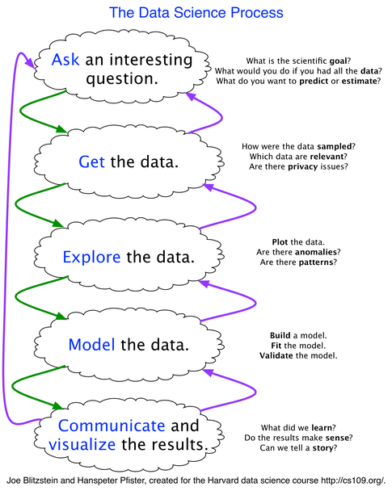

Now that I have my personal web site up and running on *github.io*, I will start logging periodic blogs as promised on my aboutme tab. For this web site, I used [Jekyll](http://jekyllrb.com/), a simple blog-aware, static site generator. Although it is not required to host web site on github, I’ve also installed Jekyll server on my home [server](http://jekyllrb.com/docs/installation/) to host the replica of what you see here. This is great because I can experiment on a simulated site and push the final version to github.io. gh-pages branch for publishing on the web. I’d like to pause here and thank [Dean Attali](http://deanattali.com/) for his great work on the *beautiful-jekyll* them. That is the template I forked and used for this site. Once I grasped the concept of *jekyll + RStudio + github gh-pages*, it was smooth sailing. Perhaps I will dedicate a blog on ‘how to’ for those who are interested in getting their own Jekyll server up and running.

It has been said that to be effective in *Data Science*, one should start with a *“sharp”* question. Follow the question by collecting a high quality accurate *“connected”* data. Taking time to understand the data using [exploratory data analysis](https://leanpub.com/exdata) tools/techniques will help to get to the answer efficiently. Domain expertise in the subject matter, or having access to one, is key to adding a custom feature to the data that illuminate gems that otherwise would be hidden .

Lastly, but importantly, once the answer is obtained by training a model utilizing the appropriate machine learning algorithm given the question, it is advantageous to understand how the derived answer will be utlized and delivred. That is that, will an API key get generated and distributed to customers or internal staff. Should a web app get developed, using shiny for example, or does it need to be hosted on web service providers such y-hat and Microsoft Azure.

Signing off for now. See you on my next blog!